# Comparación de modelos

Santiago Alonso-Díaz, PhD  
Universidad Javeriana

¿Cuál modelo representa mejor la realidad?

[figure not shown]

# Modelos jerárquicos

[figure not shown]

Principales fuentes: Gelman, et al (2013); Kruschke (2014).

Hay muchas estructuras jerarquicas:

- Probabilidad de supervivencia COVID
  - Depende de país.
    - Depende del hospital.
- Actividad M1 en decisiones económicas (motor cortex)
  - Depende de SMA (supplementary motor area)
    - Depende de IPS (intraparietal sulcus; acum. evidencia)
      - Depende de vmPFC (ventromedial prefrontal cortex; valor subjetivo)

## Primer ejemplo: Riesgo de tumor en ratas

Descripción: determinar $\theta$, la probabilidad de tumor en ratas de laboratorio (F344) que no reciben medicamento experimental.

Datos: 1 experimento que se acaba de hacer. 70 grupos de ratas testeadas antes.

Este ejemplo se va a modelar de forma jerárquica y con priors basados en data anterior.

```python
#Data
rats = pd.DataFrame(
    np.loadtxt("data/5_CB/rats.asc", skiprows=1),
    columns = ['y','n']
)
rats.head() #y: with tumor; n: total rats
```

|  | y | n |
| --- | --- | --- |
| 0 | 0.0 | 20.0 |
| 1 | 0.0 | 20.0 |
| 2 | 0.0 | 20.0 |
| 3 | 0.0 | 20.0 |
| 4 | 0.0 | 20.0 |

71 experimentos con j grupos de ratas.

$\theta_j$ depende de `hiperparámetros` $\alpha, \beta$:

Hiperparámetros reflejan condiciones del grupo, experimento, o día.

[figure not shown]

Las distribuciones para $y_j$ & $\theta_j$:

- Beta esta entre [0,1], perfecto para proporciones.
- Binomial, es discreta para conteos.

La distribución $p(\alpha,\beta)$:

- Uniforme entre $$\left[\frac{\alpha}{\alpha+\beta}, (\alpha+\beta)^{-1/2} \right]$$
- El 1er extremo es el promedio de $\theta_j$
- El 2do extremo depende del denominador del promedio de $\theta_j$: $\alpha + \beta$
- $(\alpha + \beta)^{-5/2}$, es luego de volver a las variables originales (ver Gelman, et al, 2013, Hierarchical Models).

```python
# p(alpha,beta) en log (el algoritmo trabaja con logs)
def logp_ab(a,b):
    return tt.log(tt.pow(a+b, -5/2))
with pm.Model() as model:
    a = pm.Uniform('alpha', 0.05, 100)
    b = pm.Uniform('beta', 0.05, 100)
    pm.Potential('p(a, b)', logp_ab(a,b))
    #Pueden remover el Potential (es simila a increase_log de stan)
    #(pero ver Gelman, 2013, Ch 5, ed 3)
    #El algoritmo no falla si limitamos alpha y beta.

    theta = pm.Beta('theta', alpha=a, beta=b,
                    shape=rats.shape[0])

    y = pm.Binomial('y', p=theta, n=rats.loc[:,'n'],
                    observed=rats.loc[:,'y'])

    # Sampleo
    trace = pm.sample(5000, target_accept=.95)
    #the step size in PyMC3 is tuned automatically during warm up,
    #but we can coerce smaller step sizes by tweaking the configuration
    #of PyMC3’s adaptation routine. In particular, we can increase the
    #target_accept parameter from its default value of 0.8 closer
    #to its maximum value of 1
    ##posterior_predictive = pm.sample_posterior_predictive(trace)
```

```
Auto-assigning NUTS sampler...
Initializing NUTS using jitter+adapt_diag...
Multiprocess sampling (4 chains in 4 jobs)
NUTS: [theta, beta, alpha]
```

100.00% [24000/24000 00:40<00:00 Sampling 4 chains, 0 divergences]

```
Sampling 4 chains for 1_000 tune and 5_000 draw iterations (4_000 + 20_000 draws total) took 44 seconds.
The number of effective samples is smaller than 25% for some parameters.
```

Combina bien

[figure not shown]

Posterior de los hiperparametros

[figure not shown]

El modelo predice bien las proporciones (linea punteada modelo separado)

[figure not shown]

```python
# Comparación del modelo separado (cada experimento aparte)
# y el jerárquico.
x = np.linspace(0, 1, 250)
# binomial likelihood, beta (1,1) prior ,
# resulting posterior is beta(y+1,n-y+1)
# Por claridad, solo cada 7a distribución
theta_sep = st.beta.rvs(a = rats.iloc[0:-1:7,0] + 1,
                        b = rats.iloc[0:-1:7,1] - rats.iloc[0:-1:7,0] + 1,
                        size = [5000,rats.iloc[0:-1:7,0].shape[0]])
```

$\theta_j$ son más angostos que los del modelo separado. Modelo jeráquico tiene menos incertidumbre agrupandolos via $\alpha$ y $\beta$.  
Pero ¿cuál escoger? Veamos otro ejemplo primero.

[figure not shown]

## Segundo ejemplo: ocho colegios

Problema: ¿programas de entrenamiento mejoran puntajes en la prueba de ingreso a la universidad?

Detalles: 8 colegios, cada uno con su propio programa de entrenamiento.

Data: aumento en puntaje (grupo control de cada colegio no hizo el entrenamiento)

Modelo jerárquico

[figure not shown]

```python
# SAT-example data (SAT: Scholastic Aptitude Test)
# y is the estimated treatment effect
# s is the standard error of effect estimate
y = np.array([28,  8, -3,  7, -1,  1, 18, 12])
s = np.array([15, 10, 16, 11,  9, 11, 10, 18])
schools = pd.DataFrame({"Efecto":y, 'SE':s})
schools
```

|  | Efecto | SE |
| --- | --- | --- |
| 0 | 28 | 15 |
| 1 | 8 | 10 |
| 2 | -3 | 16 |
| 3 | 7 | 11 |
| 4 | -1 | 9 |
| 5 | 1 | 11 |
| 6 | 18 | 10 |
| 7 | 12 | 18 |

```python
with pm.Model() as model:
    mu = pm.Uniform('mu', 0, 30)
    tau = pm.Uniform('tau', 0, 30)

    theta = pm.Normal('theta', mu=mu, sigma=tau,
                      shape=schools.shape[0])

    y = pm.Normal('y', mu = theta, sigma = schools.loc[:,'SE'],
                  observed = schools.loc[:,'Efecto'])

    # Sampleo
    trace = pm.sample(5000, tune = 1000, target_accept = 0.99)
    posterior_predictive = pm.sample_posterior_predictive(trace)
```

```
Auto-assigning NUTS sampler...
Initializing NUTS using jitter+adapt_diag...
Multiprocess sampling (4 chains in 4 jobs)
NUTS: [theta, tau, mu]
```

100.00% [24000/24000 00:52<00:00 Sampling 4 chains, 54 divergences]

```
Sampling 4 chains for 1_000 tune and 5_000 draw iterations (4_000 + 20_000 draws total) took 53 seconds.
There were 15 divergences after tuning. Increase `target_accept` or reparameterize.
There were 11 divergences after tuning. Increase `target_accept` or reparameterize.
There were 14 divergences after tuning. Increase `target_accept` or reparameterize.
The acceptance probability does not match the target. It is 0.9688440056834188, but should be close to 0.99. Try to increase the number of tuning steps.
There were 14 divergences after tuning. Increase `target_accept` or reparameterize.
The acceptance probability does not match the target. It is 0.9627708247412117, but should be close to 0.99. Try to increase the number of tuning steps.
The number of effective samples is smaller than 10% for some parameters.
```

100.00% [20000/20000 00:09<00:00]

Combina bien

[figure not shown]

El proceso latente de donde salen los efectos del promedio entrenamiento ($\mu$) no es muy ruidoso

[figure not shown]

Un efecto tan fuerte como el de la escuela A (28 puntos de incremento) parece improbable, aún con hiperparametro $\tau$ alto

[figure not shown]

```python
az.summary(data)
```

|  | mean | sd | hdi_3% | hdi_97% | mcse_mean | mcse_sd | ess_mean | ess_sd | ess_bulk | ess_tail | r_hat |
| --- | --- | --- | --- | --- | --- | --- | --- | --- | --- | --- | --- |
| theta[0] | 11.662 | 8.216 | -2.097 | 27.994 | 0.149 | 0.105 | 3059.0 | 3059.0 | 2781.0 | 7078.0 | 1.00 |
| theta[1] | 8.031 | 6.174 | -3.531 | 20.165 | 0.079 | 0.059 | 6133.0 | 5518.0 | 5630.0 | 9880.0 | 1.00 |
| theta[2] | 6.444 | 7.478 | -7.796 | 21.110 | 0.087 | 0.068 | 7324.0 | 6105.0 | 6553.0 | 7880.0 | 1.00 |
| theta[3] | 7.945 | 6.436 | -4.240 | 20.383 | 0.081 | 0.060 | 6263.0 | 5781.0 | 5807.0 | 10054.0 | 1.00 |
| theta[4] | 5.293 | 6.074 | -6.982 | 16.342 | 0.089 | 0.063 | 4663.0 | 4663.0 | 4577.0 | 8572.0 | 1.00 |
| theta[5] | 6.377 | 6.566 | -6.495 | 18.873 | 0.083 | 0.060 | 6276.0 | 5920.0 | 5763.0 | 7690.0 | 1.00 |
| theta[6] | 10.840 | 6.673 | -0.279 | 24.326 | 0.130 | 0.092 | 2631.0 | 2631.0 | 2479.0 | 4333.0 | 1.00 |
| theta[7] | 8.805 | 7.620 | -5.063 | 24.165 | 0.099 | 0.077 | 5894.0 | 4860.0 | 5361.0 | 8612.0 | 1.00 |
| mu | 8.417 | 4.552 | 0.001 | 15.884 | 0.084 | 0.059 | 2931.0 | 2931.0 | 2554.0 | 2436.0 | 1.00 |
| tau | 6.508 | 4.948 | 0.241 | 15.460 | 0.150 | 0.106 | 1090.0 | 1090.0 | 633.0 | 534.0 | 1.01 |

El programa de la escuela A es bueno, pero parece que no hay evidencia que sea siempre el mejor

[figure not shown]

```python
# Probabilidad que el programa de la escuela A
# sea mejor que el del peor en los datos
conteo = np.sum(trace['theta'][:,0]>trace['theta'][:,2])
prob = conteo/trace['theta'].shape[0]
print("Probabilidad que el programa de la escuela A sea mejor que de la escuela C: ", np.round(prob,2))
```

```
Probabilidad que el programa de la escuela A sea mejor que de la escuela C:  0.68
```

### Ejercicios (Fuente: Gelman, et al, 3era ed.)

1. Utilicé las muestras del ejemplo de ocho colegios:
   - Para cada escuela, calcule la probabilidad que su programa es el mejor de todos.
   - Para cada par de escuelas j,k calcule la probabilidad que el programa j es mejor que el programa k.

```python
#Escriba su código acá
```

1. Repita 1 con $\tau$ fijo y muy grande (esto es equivalente a una estimación separada por colegio). Discuta las diferencias con los resultados del punto 1.

```python
#Escriba su código acá
```

1. Utilice la data de las ratas pero ahora trabaje en la escala log-odds. Para ello, tome muestras de $logit(\theta_j) \sim Normal(\mu, \tau)$, donde $\tau$ es la desviación estandar. Tip: calcule el logit de $\mu$ y $\tau$. Interprete los resultados en esa escala.

```python
#Escriba su código acá
```

1. En los alrededores del campus de una universidad se hizo un conteo de tráfico de bicicletas y otros vehiculos. Sesenta bloques se seleccionaron y se observaron por una hora. Los bloques se escogieron acorde a su nivel de actividad (bien ocupado, ocupación normal, y residencial) y si tenían bicirutas o no. La data la puede encontrar en transit.csv. Centrese en las 10 primeras filas. Haga lo siguiente:
   - Un modelo jerárquico como el del tumor de las ratas. Ahora n es el total de vehiculos (bicis+otros) y la variable de interés es la proporción de bicis. Es decir, infiera $\theta_j$, la proporción latente de bicicletas de cada bloque, con la data disponible (solo las 10 primeras filas).
   - Compare la posterior del parámetro $\theta_j$ con las proporciones que hay en la data en cada bloque (# de bicicletas / # vehiculos incluyendo bicicletas). Comente cómo difieren (o no) la proporciones de la data y la inferencia de la posterior del parámetro $\theta_j$
   - Calcule el intervalo posterior al 95% de la proporción de tráfico de bicicletas en todos los bloques. Agrupe todos los $\theta_j$, queremos un intervalo general.
   - Corra el modelo ahora con los siguientes priors y likelihood:
     - Likelihood para el conteo de bicicletas es una $Poisson(\theta_j)$. Ahora $\theta_j$ es el número promedio de bicis por hora.
     - Prior $Gamma(\alpha,\beta)$ para $\theta_j$. Asigne uniformes para los hiperparámetros $\alpha$ y $\beta$
     - Haga un gráfica con los hiperparámetros (eje x: $\alpha$, eje y: $\beta$)

```python
#Escriba su código acá
```

# Comparar modelos

En la anterior sección comparamos datos vs. posterior (ver ejemplo ratas).

Vamos a ver más técnicas/aproximaciones al problema de escoger el mejor modelo.

Una aproximación es pensar el problema como uno jerárquico.  
Dos modelos (m) con diferentes priors y likelihoods.  
La distribución categórica al tope de la jerárquia tiene hiperparámetros. La inferencia los determina.

[figure not shown]

[figure not shown]

El problema en representación jerárquica.  
Buscamos las prob. posteriores de m=1, m=2 dado los lanzamientos de la moneda $y_i$

[figure not shown]

```python
#Data
N=9
z=6
y_o = [0]*(N-z) +  [1]*z
y_o
```

```
[0, 0, 0, 1, 1, 1, 1, 1, 1]
```

```python
# Models to compare
m1_info = np.array([3,9])
m2_info = np.array([9,3])
# Inference
with pm.Model() as model:
    #Prior for m (model)
    mi = pm.DiscreteUniform('model_index', lower=0, upper=1)

    #Samples from the models to test
    thetaM1 = pm.Beta('thetaM1', m1_info[0], m1_info[1] )
    thetaM2 = pm.Beta('thetaM2', m2_info[0], m2_info[1] )

    #Likelihood
    theta = pm.Deterministic('theta', (1-mi)*thetaM1 + (mi)*thetaM2)
    y = pm.Bernoulli('y', theta, observed = y_o)

    #Muestras
    start = pm.find_MAP()
    step = pm.Metropolis()
    trace = pm.sample(10000, step = step, start = start)
    burned_trace = trace[5000:] #burn in ( para este ejemplo, grande por conveniencia: graficas con poco MB).
```

100.00% [7/7 00:00<00:00 logp = -7.6129, ||grad|| = 3.2882]

```
Multiprocess sampling (4 chains in 4 jobs)
CompoundStep
>Metropolis: [thetaM2]
>Metropolis: [thetaM1]
>Metropolis: [model_index]
```

100.00% [44000/44000 00:09<00:00 Sampling 4 chains, 0 divergences]

```
Sampling 4 chains for 1_000 tune and 10_000 draw iterations (4_000 + 40_000 draws total) took 10 seconds.
The number of effective samples is smaller than 25% for some parameters.
```

[figure not shown]

```python
print("p(m=2|D): ", np.round(burned_trace['model_index'].mean(),4))
print("p(theta|D): ", np.round(burned_trace['theta'].mean(),4))
print("Prop. data: ", np.round(z/N,4)) #Data
```

```
p(m=2|D):  0.8706
p(theta|D):  0.678
Prop. data:  0.6667
```

El posterior del indice sugiere que el modelo 2 es mejor para la data.

[figure not shown]

Asumimos priors diferentes ( $\theta_{M1}$, $\theta_{M2}$ ), y el mismo likelihood.

Es perfectamente valido que los modelos también tengan diferentes likelihoods.

Vemos como incluirlo en nuestro modelo.

```python
# No vamos a correr el modelo, pues no tiene sentido.
# Es solo para ver cómo se puede considerar diferentes
# likelihoods
with model:
    #pm.math.eq(A, B) checks if A==B.
    theta_cond = pm.math.switch(pm.math.eq(mi, 0),
                                theta, #1er likelihood
                                2*theta #2do likelihood
                               )
    y_cond = pm.Bernoulli('y_cond', theta_cond, observed = y_o)
```

## Bayes factor

Una métrica propuesta para cuantificar la ventaja de un modelo sobre otro es con `Bayes factor`. La definición es

$$BF = \frac{p(Data|Modelo_1)}{p(Data|Modelo_2)}$$

Otra formulación equivalente es (no la vamos a demostrar):

\begin{align} BF &= \frac{Post_{odds}}{Prior_{odds}}\\ &= \frac{\frac{p(Modelo_1|Data)}{p(Modelo_2|Data)}}{\frac{p(Modelo_1)}{p(Modelo_2)}} \end{align}

```python
# Bayes factor para el ejemplo de la moneda
p_M2 = burned_trace['model_index'].mean() # i.e. la tasa de muestras de M2
Post_odds = (p_M2)/(1-p_M2)
Prior_odds = 0.5/0.5
BF = Post_odds / Prior_odds # Bayes Factor a favor de M2
BF
```

```
6.727975270479137
```

Esta vez fue fácil de calcular pero el Bayes Factor requiere computación intensiva pues el marginal likelihood son integrales multiples sobre muchos parámetros.

Veamos otra forma de cuantificar ventajas de modelos.

## Information Criterion (IC)

Basado en [PyMC website](https://docs.pymc.io/notebooks/model_comparison.html)

Los information criterion (IC) son medidas para comparar modelos. Hay varios, por ejemplo, BIC, AIC, WAIC. Todos se basan en una función del likelihood llamada deviance ([Gelman, et al](http://www.stat.columbia.edu/~gelman/research/published/waic_understand3.pdf)).

Veamos WAIC. Esta es la formula:

$$WAIC = -2lppd +2p_{waic}$$

lppd es log pointwise predictive density (i.e. likelihood). En la práctica usamos las S muestras del sampleador $\theta^s$. n es número de datos: $$computed \; lppd = \sum_{i=1}^n log \left(\frac{1}{S}\sum_{s=1}^S p(y_i|\theta^s)\right)$$

$p_{waic}$ es parámetros efectivos, un termino para penalizar modelos complejos:

$$p_{waic} = \sum_{i=1}^n V_{s}^S (log(p(y_i|\theta^s))$$

V es varianza

Volvamos a la data de las 8 escuelas.

Objetivo: inferir los efectos de entrenamiento en puntajes de ingreso a la universidad.  
Modelos:

- Pooled: UN solo efecto compartido para las 8
- Hierarchical: Efectos diferentes para cada escuela

Data: 8 efectos/ganancias en puntajes y desviación estándar ($\sigma$)

```python
J = 8
y = np.array([28,  8, -3,  7, -1,  1, 18, 12])
sigma = np.array([15, 10, 16, 11,  9, 11, 10, 18])
```

```python
with pm.Model() as pooled:
    mu = pm.Normal('mu', 0, sd=1e6)
    obs = pm.Normal('obs', mu, sd=sigma, observed=y)
    trace_p = pm.sample(2000)

with pm.Model() as hierarchical:
    eta = pm.Normal('eta', 0, 1, shape=J)
    mu = pm.Normal('mu', 0, sd=1e6)
    tau = pm.HalfCauchy('tau', 5)
    theta = pm.Deterministic('theta', mu + tau*eta)
    obs = pm.Normal('obs', theta, sd=sigma, observed=y)
    trace_h = pm.sample(2000, target_accept=0.99)
```

```
Auto-assigning NUTS sampler...
Initializing NUTS using jitter+adapt_diag...
Multiprocess sampling (4 chains in 4 jobs)
NUTS: [mu]
```

100.00% [12000/12000 00:02<00:00 Sampling 4 chains, 0 divergences]

```
Sampling 4 chains for 1_000 tune and 2_000 draw iterations (4_000 + 8_000 draws total) took 3 seconds.
Auto-assigning NUTS sampler...
Initializing NUTS using jitter+adapt_diag...
Multiprocess sampling (4 chains in 4 jobs)
NUTS: [tau, mu, eta]
```

100.00% [12000/12000 00:08<00:00 Sampling 4 chains, 0 divergences]

```
Sampling 4 chains for 1_000 tune and 2_000 draw iterations (4_000 + 8_000 draws total) took 9 seconds.
```

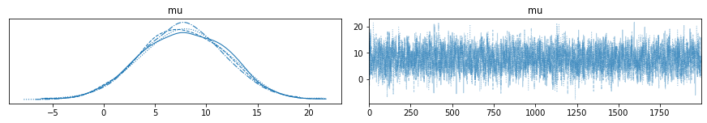

```python
with pooled:
    pm.traceplot(trace_p, var_names=['mu']);
```

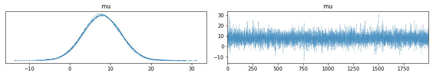

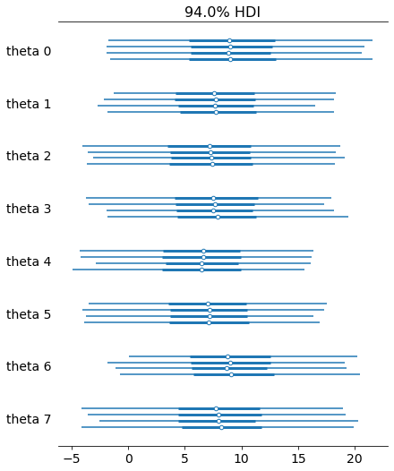

```python
with hierarchical:
    pm.traceplot(trace_h, var_names=['mu']);
    pm.forestplot(trace_h, var_names=['theta']);
```

Podemos calcular WAIC con PyMC

Para comparar WAIC de diferentes modelos. También loo.

```python
with pooled:
    df_comp_WAIC = pm.compare({'hierarchical': trace_h,
                               'pooled': trace_p}, ic = 'waic')
    df_comp_loo = pm.compare({'hierarchical': trace_h,
                              'pooled': trace_p}, ic = 'loo')
```

```python
display(df_comp_WAIC) # waic
display(df_comp_loo) # leave-one-out cross validation
#rank: order of models (worst to best); waic/loo: self-explained
#p_waic: eff. number of parameters; d_waic/d_loo: difference in ...,
#se: of waic/loo; dse: of d_waic/d_loo; warning: should be false
```

|  | rank | waic | p_waic | d_waic | weight | se | dse | warning | waic_scale |
| --- | --- | --- | --- | --- | --- | --- | --- | --- | --- |
| pooled | 0 | -30.5587 | 0.668387 | 0 | 0.554159 | 1.04875 | 0 | False | log |
| hierarchical | 1 | -30.7746 | 0.845831 | 0.215917 | 0.445841 | 1.0563 | 0.0600195 | False | log |

|  | rank | loo | p_loo | d_loo | weight | se | dse | warning | loo_scale |
| --- | --- | --- | --- | --- | --- | --- | --- | --- | --- |
| pooled | 0 | -30.5726 | 0.682366 | 0 | 0.570608 | 1.00807 | 0 | False | log |
| hierarchical | 1 | -30.8531 | 0.924314 | 0.28042 | 0.429392 | 1.01255 | 0.0953751 | True | log |

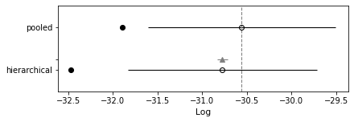

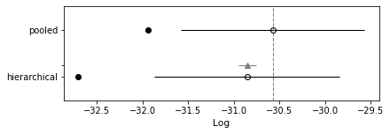

```python
with pooled:
    pm.compareplot(df_comp_WAIC);
    pm.compareplot(df_comp_loo);
```

El modelo jerárquico no dominó al pooled. Ambos hacen un buen trabajo.

# Regresiones

Basado en Gelman et al y en [Prasad Ostwal](https://ostwalprasad.github.io/machine-learning/Bayesian-Linear-Regression-using-PyMC3.html)

En una regresión tradicional inferimos parametros de una normal que cambia de promedio en función del valor de variables independientes X:

[figure not shown]

$$ y|\beta, \sigma, X \sim Normal(X \beta,\sigma I)$$

$I$ es la identidad; asumimos homocedasticidad.

La aproximación bayesiana permite inferir $\beta$ y $\sigma$ con `incertidumbre`

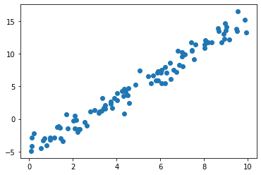

```python
n = 100
x = np.random.uniform(0,10,n)
y = 2 * x - 5 + np.random.normal(0,1,n)
plt.scatter(x, y);
```

```python
with pm.Model() as basic_model:

    #Priors
    alpha = pm.Normal('alpha', mu=0, sd=10)
    beta = pm.Normal('beta', mu=0, sd=10)
    sigma = pm.HalfNormal('sigma', sd=3)

    # Deterministics
    #mu = pm.Deterministic("mu", alpha + beta*x) #to save in trace the deterministic value
    mu = alpha + beta*x

    # Likelihood
    Ylikelihood = pm.Normal('Ylikelihood', mu=mu, sd=sigma, observed=y)

    # Samples
    trace = pm.sample(draws=3000)
```

```
Auto-assigning NUTS sampler...
Initializing NUTS using jitter+adapt_diag...
Multiprocess sampling (4 chains in 4 jobs)
NUTS: [sigma, beta, alpha]
```

100.00% [16000/16000 00:04<00:00 Sampling 4 chains, 0 divergences]

```
Sampling 4 chains for 1_000 tune and 3_000 draw iterations (4_000 + 12_000 draws total) took 6 seconds.
The acceptance probability does not match the target. It is 0.8849638452892347, but should be close to 0.8. Try to increase the number of tuning steps.
```

[figure not shown]

```python
with basic_model:
    print(pm.summary(trace).round(2))
    #pm.plots.forestplot(trace)
```

```
       mean    sd  hdi_3%  hdi_97%  mcse_mean  mcse_sd  ess_mean  ess_sd  \
alpha -4.91  0.22   -5.31    -4.49        0.0      0.0    5388.0  5364.0
beta   2.01  0.04    1.94     2.09        0.0      0.0    5381.0  5373.0
sigma  1.05  0.08    0.92     1.21        0.0      0.0    6651.0  6611.0

       ess_bulk  ess_tail  r_hat
alpha    5390.0    5660.0    1.0
beta     5394.0    5758.0    1.0
sigma    6665.0    6080.0    1.0
```

[figure not shown]

Podemos revisar el modelo de varias formas. Empecemos con posterior predictive checks (i.e. simular nueva data). Usemos el promedio de $y$ en la data para comparar.

```python
with basic_model:
    ypred = pm.sampling.sample_posterior_predictive(trace=trace)
    y_sample_posterior_predictive = np.asarray(ypred['Ylikelihood'])
```

100.00% [12000/12000 00:11<00:00]

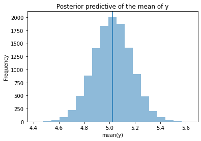

```python
_, ax = plt.subplots()
ax.hist([n.mean() for n in y_sample_posterior_predictive], bins=19, alpha=0.5)
ax.axvline(y.mean()) #actual data
ax.set(title='Posterior predictive of the mean of y', xlabel='mean(y)', ylabel='Frequency');
```

El posterior predictive check nos dice que el modelo reproduce una estadística importante (el promedio de y).

Ahora veamos si un modelo nulo, con solo intercepto, nos sirve. Usaremos WAIC.

```python
with pm.Model() as null_model:
    #Priors
    alpha = pm.Normal('alpha', mu=0, sd=10)
    sigma = pm.HalfNormal('sigma', sd=4)

    # Deterministics
    #mu = pm.Deterministic("mu", alpha + beta*x) #to save in trace the deterministic value
    mu = alpha

    # Likelihood
    Ylikelihood = pm.Normal('Ylikelihood', mu=mu, sd=sigma, observed=y)

    # Samples
    trace_null = pm.sample(draws=3000)
```

```
Auto-assigning NUTS sampler...
Initializing NUTS using jitter+adapt_diag...
Multiprocess sampling (4 chains in 4 jobs)
NUTS: [sigma, alpha]
```

100.00% [16000/16000 00:03<00:00 Sampling 4 chains, 0 divergences]

```
Sampling 4 chains for 1_000 tune and 3_000 draw iterations (4_000 + 12_000 draws total) took 3 seconds.
```

```python
with null_model:
    print(pm.summary(trace_null).round(2))
```

```
       mean    sd  hdi_3%  hdi_97%  mcse_mean  mcse_sd  ess_mean   ess_sd  \
alpha  5.00  0.58    3.89     6.07       0.01      0.0   10880.0  10785.0
sigma  5.79  0.41    5.05     6.59       0.00      0.0   10879.0  10697.0

       ess_bulk  ess_tail  r_hat
alpha   10890.0    8179.0    1.0
sigma   11001.0    8565.0    1.0
```

```python
with null_model:
    df_comp_WAIC = pm.compare({'Base': trace,
                               'Null': trace_null}, ic = 'waic')
display(df_comp_WAIC) # waic
```

|  | rank | waic | p_waic | d_waic | weight | se | dse | warning | waic_scale |
| --- | --- | --- | --- | --- | --- | --- | --- | --- | --- |
| Null | 0 | -318.375 | 1.41601 | 0 | NaN | 2355.38 | 0 | False | log |
| Base | 1 | -18478.5 | 14613.2 | 18160.1 | 0 | 4.67814 | 2311.85 | True | log |

# Conclusión

Hay modelos que explican mejor la data.

Podemos compararlos cualitativa (e.g. posterior predictive checks) o cuantitativamente (e.g. waic)

No hay modelo perfecto